# ML ASS3 CHURN PREDICTION

KIBIDI

2026-04-14

Center for Data Analytics and Modeling Chuka University Machine Learning Assignment 3 Multi-Model Classification for Customer Churn Prediction Course: Machine Learning Methods

Instructor: Lumumba W. Victor Email: lumumbavictor172@gmail.com Date Issued: April 13, 2026 Due Date: 24th April 2026 Total Marks: 100

Learning Objectives • Implement multiple classification algorithms in R (Logistic, KNN, SVM, RF) • Apply appropriate preprocessing for different model types • Create and use trainControl schemes for cross-validation • Evaluate and compare model performance using multiple metrics • Interpret model-specific outputs (coefficients, importance, support vectors) • Make evidence-based model selection recommendations Assignment 3 CDAM- Machine Learning

1 General Instructions • This assignment must be completed individually. • Submit your work as a PDF report and the R script (.R or .Rmd). • All code must be well-commented and reproducible (set seed = 2026). • Use the provided dataset: business_churn_data.RData. • Plots and tables must be clearly labeled with captions. • Late submissions will incur a penalty of 10% per day. • Plagiarism will result in zero marks for all parties involved.

#Set working directory

```r
setwd("C:/331199")
```

3.1 Task 1: Data Import and Exploration (10 Marks)

#3.1.1. Load all necessary libraries

```r
library(tidyverse)
library(caret)
library(pROC)
library(e1071)
library(class)
library(randomForest)
```

```r
library(ggplot2)
```

#3.1.2.a) Import the dataset business_churn_data.RData using load().

```r
load('business_churn_data.RData')
```

#3.1.2.b) # Verify object loaded

```r
ls()
```

```
## [1] "business_data"
```

#3.1.3.a) Display the structure of the data (str())

```r
str(business_data)
```

```
## 'data.frame':    2560 obs. of  17 variables:
##  $ CustomerID       : int  10001 10002 10003 10004 10005 10006 10007 10008 10009 10010 ...
##  $ Age              : num  44 25 40 37 30 18 29 26 39 32 ...
##  $ Gender           : Factor w/ 2 levels "Female","Male": 2 2 2 2 2 2 2 1 2 1 ...
##  $ TenureMonths     : num  4 6 1 2 36 47 51 37 25 20 ...
##  $ MonthlyCharges   : num  65.9 61.2 121.4 57.6 77.3 ...
##  $ TotalCharges     : num  267 379 118 119 2761 ...
##  $ ContractType     : Factor w/ 3 levels "Month-to-month",..: 1 2 1 3 1 2 1 2 1 1 ...
##  $ PaymentMethod    : Factor w/ 4 levels "Bank transfer",..: 4 1 1 3 3 1 4 3 4 4 ...
##  $ InternetService  : Factor w/ 3 levels "DSL","Fiber optic",..: 2 1 2 2 1 2 2 1 1 2 ...
##  $ OnlineSecurity   : Factor w/ 3 levels "No","No internet",..: 1 3 3 1 1 1 3 1 3 1 ...
##  $ TechSupport      : Factor w/ 3 levels "No","No internet",..: 1 1 1 1 1 1 3 1 1 3 ...
##  $ StreamingTV      : Factor w/ 3 levels "No","No internet",..: 1 3 3 3 3 1 3 1 1 1 ...
##  $ StreamingMovies  : Factor w/ 3 levels "No","No internet",..: 1 1 3 3 1 1 1 1 1 3 ...
##  $ NumSupportTickets: num  4 3 8 4 4 1 5 5 2 10 ...
##  $ SatisfactionScore: num  6 10 5 5 8 7 5 10 8 5 ...
##  $ LoyaltyProgram   : Factor w/ 2 levels "No","Yes": 2 1 1 1 1 1 1 2 2 2 ...
##  $ Churn            : int  1 0 1 0 0 0 1 0 0 1 ...
```

#3.1.3.b) Display the summary statistics .

```r
(summary(business_data))
```

```
##    CustomerID         Age           Gender      TenureMonths   MonthlyCharges
##  Min.   :10001   Min.   :18.00   Female:1209   Min.   : 1.00   Min.   : 20.00
##  1st Qu.:10641   1st Qu.:30.00   Male  :1351   1st Qu.: 8.00   1st Qu.: 58.54
##  Median :11280   Median :38.00                 Median :20.00   Median : 81.98
##  Mean   :11280   Mean   :38.26                 Mean   :25.92   Mean   : 83.21
##  3rd Qu.:11920   3rd Qu.:46.00                 3rd Qu.:42.00   3rd Qu.:106.64
##  Max.   :12560   Max.   :75.00                 Max.   :72.00   Max.   :200.00
##   TotalCharges              ContractType           PaymentMethod
##  Min.   :   19.29   Month-to-month:1405   Bank transfer   :631
##  1st Qu.:  542.12   One-year      : 628   Credit card     :539
##  Median : 1386.59   Two-year      : 527   Electronic check:903
##  Mean   : 2163.35                         Mailed check    :487
##  3rd Qu.: 3288.00
##  Max.   :12605.68
##     InternetService     OnlineSecurity      TechSupport        StreamingTV
##  DSL        : 896   No         :1148   No         :1210   No         : 943
##  Fiber optic:1148   No internet: 516   No internet: 516   No internet: 516
##  No         : 516   Yes        : 896   Yes        : 834   Yes        :1101
##
##
##
##     StreamingMovies NumSupportTickets SatisfactionScore LoyaltyProgram
##  No         :1023   Min.   : 0.000    Min.   : 1.000    No :1634
##  No internet: 516   1st Qu.: 3.000    1st Qu.: 5.000    Yes: 926
##  Yes        :1021   Median : 4.000    Median : 7.000
##                     Mean   : 4.104    Mean   : 6.811
##                     3rd Qu.: 5.000    3rd Qu.: 8.000
##                     Max.   :12.000    Max.   :10.000
##      Churn
##  Min.   :0.0000
##  1st Qu.:0.0000
##  Median :0.0000
##  Mean   :0.3168
##  3rd Qu.:1.0000
##  Max.   :1.0000
```

#3.1.4.a) Check for missing values per variable.

```r
na_count <- colSums(is.na(business_data))
na_count
```

```
##        CustomerID               Age            Gender      TenureMonths
##                 0                 0                 0                 0
##    MonthlyCharges      TotalCharges      ContractType     PaymentMethod
##                 0                 0                 0                 0
##   InternetService    OnlineSecurity       TechSupport       StreamingTV
##                 0                 0                 0                 0
##   StreamingMovies NumSupportTickets SatisfactionScore    LoyaltyProgram
##                 0                 0                 0                 0
##             Churn
##                 0
```

#3.1.4.a) Check for missing values percentage per variable.

```r
na_percent <- (na_count / nrow(business_data)) * 100
na_percent
```

```
##        CustomerID               Age            Gender      TenureMonths
##                 0                 0                 0                 0
##    MonthlyCharges      TotalCharges      ContractType     PaymentMethod
##                 0                 0                 0                 0
##   InternetService    OnlineSecurity       TechSupport       StreamingTV
##                 0                 0                 0                 0
##   StreamingMovies NumSupportTickets SatisfactionScore    LoyaltyProgram
##                 0                 0                 0                 0
##             Churn
##                 0
```

#3.1.4.c)missing values report

```r
missing_report <- data.frame(
  Variable = names(na_count),
  Missing_Count = na_count,
  Missing_Percentage = round(na_percent, 2)
)
missing_report
```

```
##                            Variable Missing_Count Missing_Percentage
## CustomerID               CustomerID             0                  0
## Age                             Age             0                  0
## Gender                       Gender             0                  0
## TenureMonths           TenureMonths             0                  0
## MonthlyCharges       MonthlyCharges             0                  0
## TotalCharges           TotalCharges             0                  0
## ContractType           ContractType             0                  0
## PaymentMethod         PaymentMethod             0                  0
## InternetService     InternetService             0                  0
## OnlineSecurity       OnlineSecurity             0                  0
## TechSupport             TechSupport             0                  0
## StreamingTV             StreamingTV             0                  0
## StreamingMovies     StreamingMovies             0                  0
## NumSupportTickets NumSupportTickets             0                  0
## SatisfactionScore SatisfactionScore             0                  0
## LoyaltyProgram       LoyaltyProgram             0                  0
## Churn                         Churn             0                  0
```

```r
missing_report[missing_report$Missing_Count > 0, ]
```

```
## [1] Variable           Missing_Count      Missing_Percentage
## <0 rows> (or 0-length row.names)
```

#3.1.4.c)visulalize missing values report bar plot

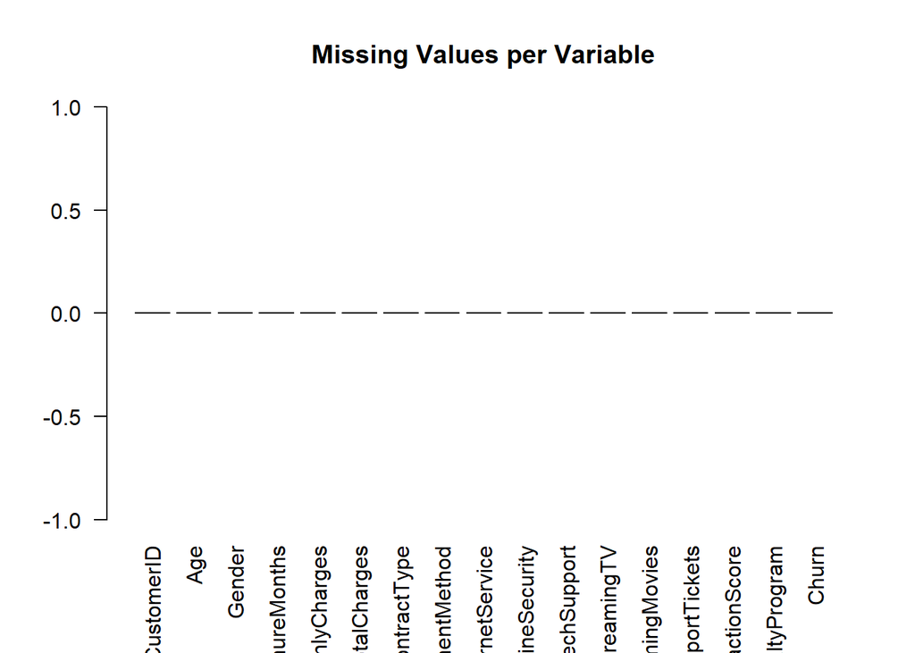

```r
barplot(na_count,
        main = "Missing Values per Variable",
        las = 2,
        col = "red")
```

#3.1.5. Visualize the distribution of the target variable Churn using a bar plot.

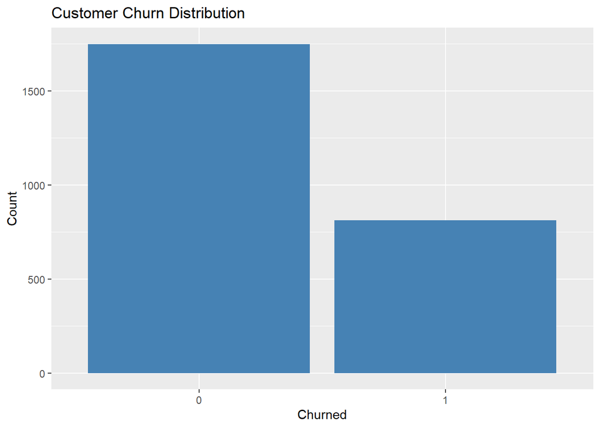

```r
ggplot(business_data, aes(x = factor(Churn))) +
geom_bar(fill = "steelblue") +
labs(title = "Customer Churn Distribution", x = "Churned", y
= "Count",
)
```

#3.1.6. Calculate and report the class imbalance ratio.

```r
prop.table(table(business_data$Churn))
```

```
##
##         0         1
## 0.6832031 0.3167969
```

```r
prop.table(table(business_data$Churn)) * 100
```

```
##
##        0        1
## 68.32031 31.67969
```

```r
class_counts <- table(business_data$Churn)
imbalance_ratio <- class_counts[1] / class_counts[2]  # 0/1 or No/Yes
imbalance_ratio
```

```
##        0
## 2.156597
```

```r
imbalance_table <- data.frame(
  Class = names(class_counts),
  Count = as.numeric(class_counts),
  Percentage = round(prop.table(class_counts) * 100, 2)
)

imbalance_table
```

```
##   Class Count Percentage.Var1 Percentage.Freq
## 1     0  1749               0           68.32
## 2     1   811               1           31.68
```

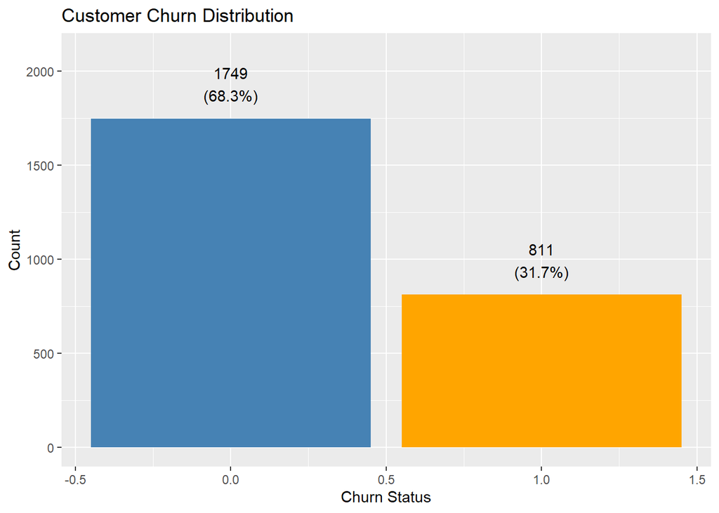

```r
ggplot(business_data, aes(x = Churn)) +
  geom_bar(fill = c("steelblue", "orange")) +
  geom_text(stat = "count",
            aes(label = paste0(..count.., "\n(",
                               round(..count../sum(..count..)*100, 1), "%)")),
            vjust = -0.5) +
  labs(
    title = "Customer Churn Distribution",
    x = "Churn Status",
    y = "Count"
  ) +
  ylim(0, max(table(business_data$Churn)) * 1.2)
```

3.2 Task 2: Data Preprocessing (15 Marks)

#3.2.1. Handle missing values (justify your method: removal or imputation). A comprehensive check for missing values revealed that all variables had complete observations (0% missing). As a result, no data cleaning procedures such as imputation or row removal were necessary. This ensures that all available data (n = 2560) was retained for model training, maximizing statistical power and model reliability.

```r
data_clean <- na.omit(business_data)
```

#3.2.1.a) check categorical variables

```r
categorical_vars <- names(data_clean)[sapply(data_clean, is.factor)]
categorical_vars
```

```
## [1] "Gender"          "ContractType"    "PaymentMethod"   "InternetService"
## [5] "OnlineSecurity"  "TechSupport"     "StreamingTV"     "StreamingMovies"
## [9] "LoyaltyProgram"
```

#3.2.2. Convert categorical variables to factors:

```r
categorical_vars <- c(
  "Gender","ContractType","PaymentMethod","InternetService",
  "OnlineSecurity","TechSupport","StreamingTV",
  "StreamingMovies","LoyaltyProgram"
)

data_clean[categorical_vars] <- lapply(
  data_clean[categorical_vars],
  factor
)
```

#3.2.3. Convert the target variable Churn to a factor with levels “No” (0) and “Yes” (1).

```r
data_clean$Churn <- factor(data_clean$Churn,
                           levels = c(0,1),
                           labels = c("No","Yes"))
```

#3.2.3.a) verify change to factor

```r
str(data_clean)
```

```
## 'data.frame':    2560 obs. of  17 variables:
##  $ CustomerID       : int  10001 10002 10003 10004 10005 10006 10007 10008 10009 10010 ...
##  $ Age              : num  44 25 40 37 30 18 29 26 39 32 ...
##  $ Gender           : Factor w/ 2 levels "Female","Male": 2 2 2 2 2 2 2 1 2 1 ...
##  $ TenureMonths     : num  4 6 1 2 36 47 51 37 25 20 ...
##  $ MonthlyCharges   : num  65.9 61.2 121.4 57.6 77.3 ...
##  $ TotalCharges     : num  267 379 118 119 2761 ...
##  $ ContractType     : Factor w/ 3 levels "Month-to-month",..: 1 2 1 3 1 2 1 2 1 1 ...
##  $ PaymentMethod    : Factor w/ 4 levels "Bank transfer",..: 4 1 1 3 3 1 4 3 4 4 ...
##  $ InternetService  : Factor w/ 3 levels "DSL","Fiber optic",..: 2 1 2 2 1 2 2 1 1 2 ...
##  $ OnlineSecurity   : Factor w/ 3 levels "No","No internet",..: 1 3 3 1 1 1 3 1 3 1 ...
##  $ TechSupport      : Factor w/ 3 levels "No","No internet",..: 1 1 1 1 1 1 3 1 1 3 ...
##  $ StreamingTV      : Factor w/ 3 levels "No","No internet",..: 1 3 3 3 3 1 3 1 1 1 ...
##  $ StreamingMovies  : Factor w/ 3 levels "No","No internet",..: 1 1 3 3 1 1 1 1 1 3 ...
##  $ NumSupportTickets: num  4 3 8 4 4 1 5 5 2 10 ...
##  $ SatisfactionScore: num  6 10 5 5 8 7 5 10 8 5 ...
##  $ LoyaltyProgram   : Factor w/ 2 levels "No","Yes": 2 1 1 1 1 1 1 2 2 2 ...
##  $ Churn            : Factor w/ 2 levels "No","Yes": 2 1 2 1 1 1 2 1 1 2 ...
```

#check numerical variables in data_clean

```r
numeric_vars <- names(data_clean)[sapply(data_clean, is.numeric)]
numeric_vars
```

```
## [1] "CustomerID"        "Age"               "TenureMonths"
## [4] "MonthlyCharges"    "TotalCharges"      "NumSupportTickets"
## [7] "SatisfactionScore"
```

#3.2.4.a) For KNN and SVM:Scale numeric predictors(mean=0, sd=1)using preProcess()from caret.

```r
numeric_vars <- c(
  "Age",
  "TenureMonths",
  "MonthlyCharges",
  "TotalCharges",
  "NumSupportTickets",
  "SatisfactionScore"
)

preproc <- preProcess(
  data_clean[, numeric_vars],
  method = c("center", "scale")
)
data_scaled <- data_clean

data_scaled[, numeric_vars] <- predict(
  preproc,
  data_clean[, numeric_vars]
)
```

#3.2.4.b)verify scaling

```r
# Before scaling
sapply(data_clean[, numeric_vars], mean)
```

```
##               Age      TenureMonths    MonthlyCharges      TotalCharges
##         38.260156         25.924609         83.213777       2163.350086
## NumSupportTickets SatisfactionScore
##          4.103906          6.810547
```

```r
sapply(data_clean[, numeric_vars], sd)
```

```
##               Age      TenureMonths    MonthlyCharges      TotalCharges
##         11.312167         20.729849         34.934249       2084.565298
## NumSupportTickets SatisfactionScore
##          2.019479          2.110758
```

```r
# After scaling
sapply(data_scaled[, numeric_vars], mean)
```

```
##               Age      TenureMonths    MonthlyCharges      TotalCharges
##     -1.272680e-16      1.755268e-17      1.169366e-16      4.783868e-17
## NumSupportTickets SatisfactionScore
##      1.887318e-16      1.122513e-17
```

```r
sapply(data_scaled[, numeric_vars], sd)
```

```
##               Age      TenureMonths    MonthlyCharges      TotalCharges
##                 1                 1                 1                 1
## NumSupportTickets SatisfactionScore
##                 1                 1
```

#3.2.5. For Random Forest: Scaling is not required (tree-based).

#3.2.6. Document your preprocessing decisions in the report. After applying centering and scaling, all numeric variables were standardized. The means are approximately zero (due to floating-point precision), and the standard deviations are exactly 1. This confirms that the scaling procedure was successful, ensuring all variables are on a comparable scale for distance-based models such as KNN and SVM.

3.3 Task 3: Data Partitioning (10 Marks)

#3.3.1. Set the seed to 2026 for reproducibility.

```r
set.seed(2026)
```

#3.3.2. Split the data into 70% training and 30% testing using stratified sampling (to preserve class balance).

```r
# Stratified split data_clean
train_index <- createDataPartition(data_clean$Churn, p = 0.7, list = FALSE)
train_data <- data_clean[train_index, ]
test_data  <- data_clean[-train_index, ]
```

#3.3.3. Report the class distribution (counts and percentages) in both training and testing sets.

```r
cat("Training Set:\n")
```

```
## Training Set:
```

```r
print(table(train_data$Churn))
```

```
##
##   No  Yes
## 1225  568
```

```r
prop.table(table(train_data$Churn))
```

```
##
##        No       Yes
## 0.6832125 0.3167875
```

```r
cat("\nTesting Set:\n")
```

```
##
## Testing Set:
```

```r
print(table(test_data$Churn))
```

```
##
##  No Yes
## 524 243
```

```r
prop.table(table(test_data$Churn))
```

```
##
##        No       Yes
## 0.6831812 0.3168188
```

#3.3.4. Verify that the class proportions are similar in both sets.

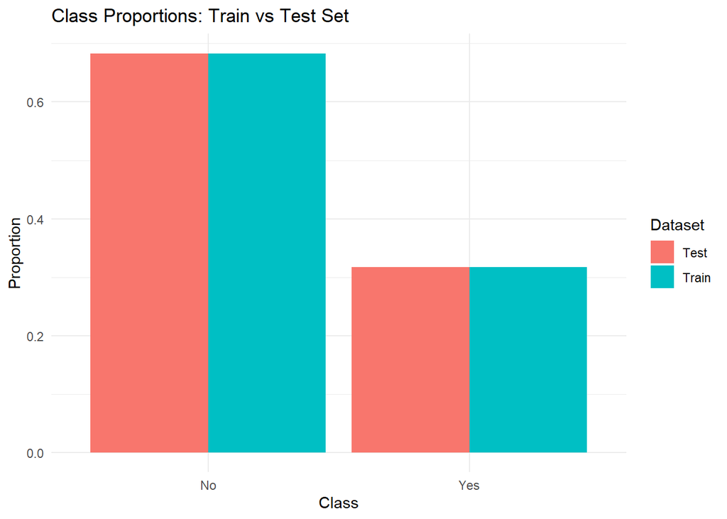

```r
train_prop <- prop.table(table(train_data$Churn))
test_prop  <- prop.table(table(test_data$Churn))

prop_df <- data.frame(
  Class = rep(names(train_prop), 2),
  Proportion = c(as.numeric(train_prop), as.numeric(test_prop)),
  Dataset = rep(c("Train", "Test"), each = length(train_prop))
)

ggplot(prop_df, aes(x = Class, y = Proportion, fill = Dataset)) +
  geom_bar(stat = "identity", position = "dodge") +
  labs(title = "Class Proportions: Train vs Test Set",
       x = "Class",
       y = "Proportion") +
  theme_minimal()
```

the bars for Train and Test are almost equal height showing good stratified split

3.4 Task 4: TrainControl Scheme (10 Marks)

#3.4.1. Define a trainControl scheme with the following specifications:

```r
ctrl <- trainControl(
  method = "cv",                     #cross-validation
  number = 10,                       #10 fold
  savePredictions = "final",         # Save predictions
  classProbs = TRUE,                 # Enable probability predictions
  summaryFunction = twoClassSummary, # ROC, Sens, Spec
  verboseIter = FALSE                # Suppress iteration output
)
```

#3.4.2. Explain why cross-validation is important for model evaluation. Cross-validation is used to evaluate model performance more reliably by repeatedly training and testing the model on different subsets of the data. This reduces bias from a single train-test split, improves generalization assessment, and helps detect over fitting. In 10-fold cross-validation, the dataset is divided into 10 parts, and the model is trained and tested 10 times, with each part serving as the test set once.

#3.4.3. Save this control object to use across all models.

3.5 Task 5: Model Training- Logistic Regression (15 Marks)

#3.5.1.a) Train a Logistic Regression model using caret::train() with method “glm”.

```r
train_data$Churn <- as.factor(train_data$Churn)
test_data$Churn  <- as.factor(test_data$Churn)

levels(train_data$Churn)
```

```
## [1] "No"  "Yes"
```

```r
train_data$Churn <- factor(train_data$Churn, levels = c("No", "Yes"))
test_data$Churn  <- factor(test_data$Churn, levels = c("No", "Yes"))


log_model <- train(
  Churn ~ Age + Gender + TenureMonths + MonthlyCharges +
    ContractType + PaymentMethod + InternetService +
    SatisfactionScore + LoyaltyProgram,
  data = train_data,
  method = "glm",
  family = binomial,
  trControl = ctrl
)
```

#3.5.1.b) Extract and report the model coefficients.

```r
coef_table <- summary(log_model$finalModel)$coefficients
coef_table
```

```
##                                     Estimate  Std. Error     z value
## (Intercept)                      0.361374656 0.425214351   0.8498647
## Age                             -0.003490675 0.005934012  -0.5882488
## GenderMale                      -0.106394220 0.131674912  -0.8080068
## TenureMonths                    -0.038534791 0.003720559 -10.3572579
## MonthlyCharges                   0.032252903 0.002296140  14.0465755
## `ContractTypeOne-year`          -0.656923770 0.156601850  -4.1948660
## `ContractTypeTwo-year`          -1.876722748 0.228915298  -8.1983282
## `PaymentMethodCredit card`      -0.059223681 0.197382999  -0.3000445
## `PaymentMethodElectronic check`  0.250781935 0.174266258   1.4390734
## `PaymentMethodMailed check`     -0.216573478 0.201882765  -1.0727685
## `InternetServiceFiber optic`     0.381953233 0.146703636   2.6035703
## InternetServiceNo               -0.980462392 0.198099223  -4.9493500
## SatisfactionScore               -0.367272179 0.033775660 -10.8738714
## LoyaltyProgramYes               -0.257883483 0.137431501  -1.8764510
##                                     Pr(>|z|)
## (Intercept)                     3.954003e-01
## Age                             5.563653e-01
## GenderMale                      4.190867e-01
## TenureMonths                    3.879238e-25
## MonthlyCharges                  8.085008e-45
## `ContractTypeOne-year`          2.730330e-05
## `ContractTypeTwo-year`          2.437531e-16
## `PaymentMethodCredit card`      7.641432e-01
## `PaymentMethodElectronic check` 1.501297e-01
## `PaymentMethodMailed check`     2.833750e-01
## `InternetServiceFiber optic`    9.225834e-03
## InternetServiceNo               7.446174e-07
## SatisfactionScore               1.535442e-27
## LoyaltyProgramYes               6.059337e-02
```

#3.5.1.c)Calculate Odds Ratios (OR) for at least 3 significant predictors: OR = eβ

```r
odds_ratios <- exp(coef(log_model$finalModel))
odds_ratios
```

```
##                     (Intercept)                             Age
##                       1.4353011                       0.9965154
##                      GenderMale                    TenureMonths
##                       0.8990701                       0.9621982
##                  MonthlyCharges          `ContractTypeOne-year`
##                       1.0327787                       0.5184437
##          `ContractTypeTwo-year`      `PaymentMethodCredit card`
##                       0.1530910                       0.9424959
## `PaymentMethodElectronic check`     `PaymentMethodMailed check`
##                       1.2850298                       0.8052734
##    `InternetServiceFiber optic`               InternetServiceNo
##                       1.4651436                       0.3751376
##               SatisfactionScore               LoyaltyProgramYes
##                       0.6926211                       0.7726853
```

#3.5.1.d)5. Interpret the Odds Ratios in the context of churn risk.

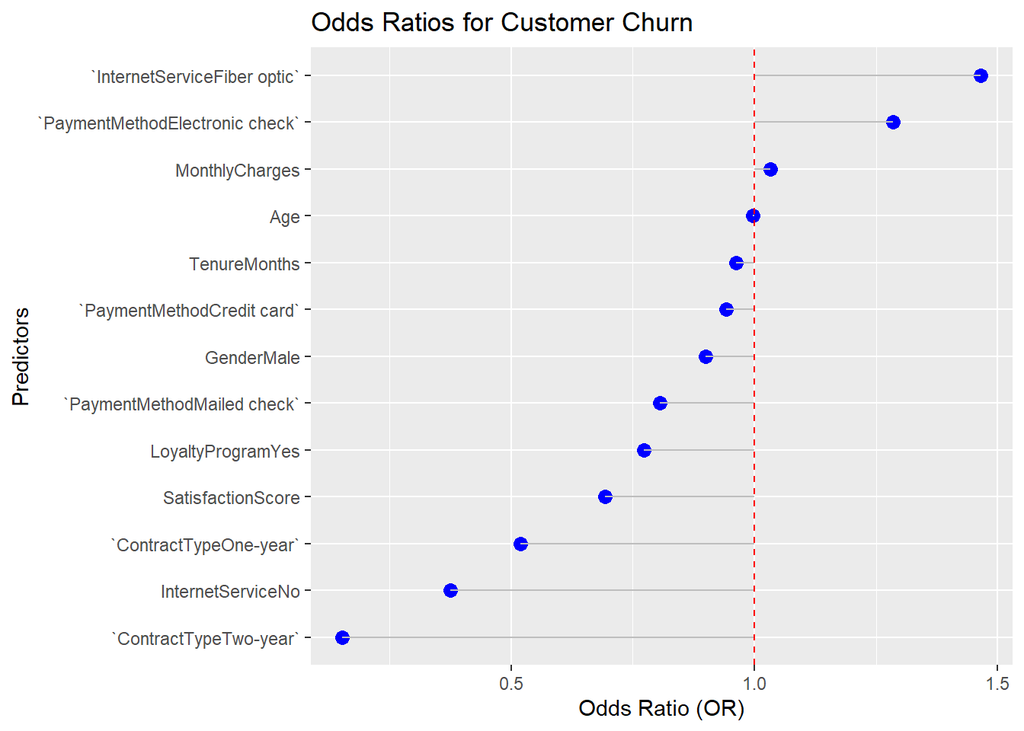

```r
# Extract coefficients and compute Odds Ratios
odds_ratios <- exp(coef(log_model$finalModel))

plot_df <- data.frame(
  Variable = names(odds_ratios),
  OddsRatio = as.numeric(odds_ratios)
)

# Remove intercept (not useful for interpretation)
plot_df <- plot_df[plot_df$Variable != "(Intercept)", ]

# Order for better visualization
plot_df <- plot_df[order(plot_df$OddsRatio), ]


ggplot(plot_df, aes(x = reorder(Variable, OddsRatio), y = OddsRatio)) +
  geom_point(size = 3, color = "blue") +
  geom_segment(aes(xend = Variable, y = 1, yend = OddsRatio), color = "gray") +
  coord_flip() +
  geom_hline(yintercept = 1, linetype = "dashed", color = "red") +
  labs(
    title = "Odds Ratios for Customer Churn",
    x = "Predictors",
    y = "Odds Ratio (OR)"
  )
```

#3.5.2. Alternatively, fit a baseline model using base R glm() function.

```r
glm_baseline <- glm(
  Churn ~ Age + Gender + TenureMonths + MonthlyCharges +
    ContractType + PaymentMethod + InternetService +
    SatisfactionScore + LoyaltyProgram,
  data = train_data,
  family = binomial
)
```

#3.5.3.a) Extract and report the model coefficients.

```r
summary(glm_baseline)$coefficients
```

```
##                                   Estimate  Std. Error     z value     Pr(>|z|)
## (Intercept)                    0.361374656 0.425214351   0.8498647 3.954003e-01
## Age                           -0.003490675 0.005934012  -0.5882488 5.563653e-01
## GenderMale                    -0.106394220 0.131674912  -0.8080068 4.190867e-01
## TenureMonths                  -0.038534791 0.003720559 -10.3572579 3.879238e-25
## MonthlyCharges                 0.032252903 0.002296140  14.0465755 8.085008e-45
## ContractTypeOne-year          -0.656923770 0.156601850  -4.1948660 2.730330e-05
## ContractTypeTwo-year          -1.876722748 0.228915298  -8.1983282 2.437531e-16
## PaymentMethodCredit card      -0.059223681 0.197382999  -0.3000445 7.641432e-01
## PaymentMethodElectronic check  0.250781935 0.174266258   1.4390734 1.501297e-01
## PaymentMethodMailed check     -0.216573478 0.201882765  -1.0727685 2.833750e-01
## InternetServiceFiber optic     0.381953233 0.146703636   2.6035703 9.225834e-03
## InternetServiceNo             -0.980462392 0.198099223  -4.9493500 7.446174e-07
## SatisfactionScore             -0.367272179 0.033775660 -10.8738714 1.535442e-27
## LoyaltyProgramYes             -0.257883483 0.137431501  -1.8764510 6.059337e-02
```

#3.5.3.b)coefficient estimates only

```r
coef(glm_baseline)
```

```
##                   (Intercept)                           Age
##                   0.361374656                  -0.003490675
##                    GenderMale                  TenureMonths
##                  -0.106394220                  -0.038534791
##                MonthlyCharges          ContractTypeOne-year
##                   0.032252903                  -0.656923770
##          ContractTypeTwo-year      PaymentMethodCredit card
##                  -1.876722748                  -0.059223681
## PaymentMethodElectronic check     PaymentMethodMailed check
##                   0.250781935                  -0.216573478
##    InternetServiceFiber optic             InternetServiceNo
##                   0.381953233                  -0.980462392
##             SatisfactionScore             LoyaltyProgramYes
##                  -0.367272179                  -0.257883483
```

#3.5.4. Calculate Odds Ratios (OR) for at least 3 significant predictors: OR = eβ

```r
coefficients <- coef(log_model$finalModel)
odds_ratios <- exp(coefficients)
print(round(odds_ratios, 3))
```

```
##                     (Intercept)                             Age
##                           1.435                           0.997
##                      GenderMale                    TenureMonths
##                           0.899                           0.962
##                  MonthlyCharges          `ContractTypeOne-year`
##                           1.033                           0.518
##          `ContractTypeTwo-year`      `PaymentMethodCredit card`
##                           0.153                           0.942
## `PaymentMethodElectronic check`     `PaymentMethodMailed check`
##                           1.285                           0.805
##    `InternetServiceFiber optic`               InternetServiceNo
##                           1.465                           0.375
##               SatisfactionScore               LoyaltyProgramYes
##                           0.693                           0.773
```

#3.5.5.a) Interpret the Odds Ratios in the context of churn risk.

```r
#Compute Odds Ratios
odds_ratios <- exp(coef(glm_baseline))

odds_df <- data.frame(
  Variable = names(odds_ratios),
  OddsRatio = as.numeric(odds_ratios)
)

odds_df
```

```
##                         Variable OddsRatio
## 1                    (Intercept) 1.4353011
## 2                            Age 0.9965154
## 3                     GenderMale 0.8990701
## 4                   TenureMonths 0.9621982
## 5                 MonthlyCharges 1.0327787
## 6           ContractTypeOne-year 0.5184437
## 7           ContractTypeTwo-year 0.1530910
## 8       PaymentMethodCredit card 0.9424959
## 9  PaymentMethodElectronic check 1.2850298
## 10     PaymentMethodMailed check 0.8052734
## 11    InternetServiceFiber optic 1.4651436
## 12             InternetServiceNo 0.3751376
## 13             SatisfactionScore 0.6926211
## 14             LoyaltyProgramYes 0.7726853
```

#3.5.5.b)visualize

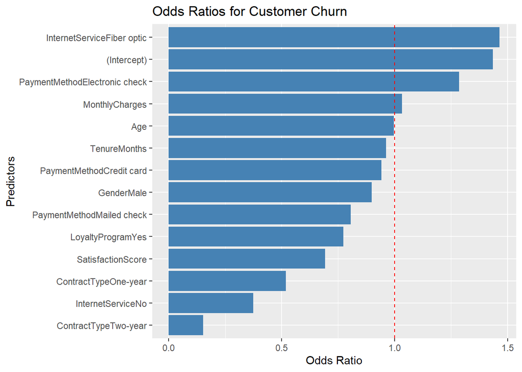

```r
odds_df <- odds_df[order(odds_df$OddsRatio), ]

ggplot(odds_df, aes(x = reorder(Variable, OddsRatio), y = OddsRatio)) +
  geom_bar(stat = "identity", fill = "steelblue") +
  coord_flip() +
  geom_hline(yintercept = 1, linetype = "dashed", color = "red") +
  labs(
    title = "Odds Ratios for Customer Churn",
    x = "Predictors",
    y = "Odds Ratio"
  )
```

3.6 Task 6: Model Training- KNN (15 Marks

```r
train_scaled <- data_scaled[train_index, ]
test_scaled  <- data_scaled[-train_index, ]


 knn_model <- train(
   Churn ~ Age + Gender + TenureMonths + MonthlyCharges +
  ContractType + PaymentMethod + InternetService +
    SatisfactionScore + LoyaltyProgram,
data = train_scaled,
method = "knn",
trControl = ctrl,
metric = "ROC",
tuneGrid = expand.grid(k = seq(1, 21, by = 2))

 )
```

#View tuning results

```r
knn_model
```

```
## k-Nearest Neighbors
##
## 1793 samples
##    9 predictor
##    2 classes: 'No', 'Yes'
##
## No pre-processing
## Resampling: Cross-Validated (10 fold)
## Summary of sample sizes: 1614, 1615, 1613, 1614, 1614, 1613, ...
## Resampling results across tuning parameters:
##
##   k   ROC        Sens       Spec
##    1  0.6531097  0.7868586  0.5193609
##    3  0.7483501  0.8023990  0.5546992
##    5  0.7745475  0.8293216  0.5546053
##    7  0.7943806  0.8562975  0.5546366
##    9  0.8107142  0.8726309  0.5441103
##   11  0.8191576  0.8791750  0.5495301
##   13  0.8273856  0.8816273  0.5740915
##   15  0.8334104  0.8840930  0.5705514
##   17  0.8402545  0.8914434  0.5476190
##   19  0.8394891  0.8873251  0.5511905
##   21  0.8402271  0.8840797  0.5598684
##
## ROC was used to select the optimal model using the largest value.
## The final value used for the model was k = 17.
```

#3.6.3. Important: Use the scaled dataset for KNN (distance-based algorithm).

#3.6.4. Report the optimal k value selected by cross-validation.

```r
knn_model$bestTune
```

```
##    k
## 9 17
```

#3.6.5. Plot accuracy vs. k to visualize the tuning results.

[figure not shown]

```r
plot(knn_model, main = "KNN: Accuracy vs k")
```

3.7 Task 7: Model Training- SVM (15 Marks)

#3.7.1. Train a Support Vector Machine model using caret::train() with method “svmRadial”.

```r
svm_model<-train(
  Churn ~ Age + Gender + TenureMonths + MonthlyCharges +
    ContractType + PaymentMethod + InternetService +
    SatisfactionScore + LoyaltyProgram,
  data = train_scaled,
  method = "svmRadial",
  trControl = ctrl,
  metric = "ROC",
  tuneGrid = expand.grid(
   C = c(0.25, 0.5, 1, 2, 4),
sigma = c(0.01, 0.05, 0.1, 0.5)
))
```

#3.7.2. Tune the hyperparameters: C (cost): 0.25, 0.5, 1, 2, 4, sigma: 0.01, 0.05, 0.1, 0.5 #3.7.3. Important: Use the scaled dataset for SVM #3.7.4. Report the optimal C and sigma values.

```r
# View optimal parameters
svm_model$bestTune
```

```
##   sigma   C
## 5  0.01 0.5
```

# Plot tuning results

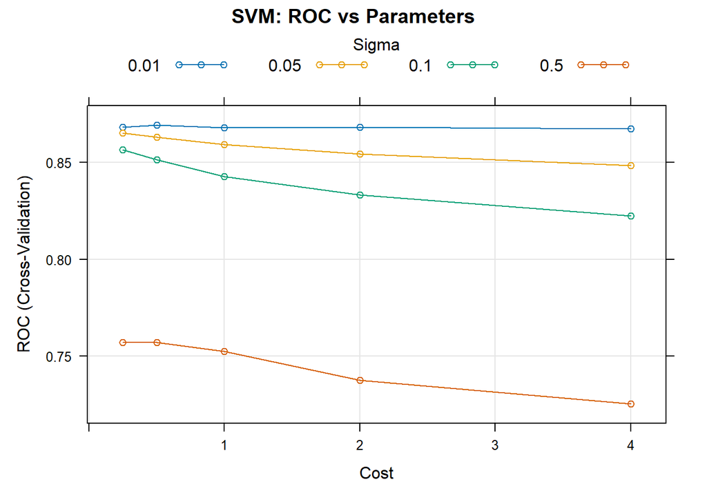

```r
plot(svm_model, main = "SVM: ROC vs Parameters")
```

3.8 Task 8: Model Training- Random Forest (15 Marks)

#3.8.1. Train a Random Forest model using caret::train() with method “rf”.

```r
rf_model <- train(
  Churn ~ Age + Gender + TenureMonths + MonthlyCharges +
    ContractType + PaymentMethod + InternetService +
    SatisfactionScore + LoyaltyProgram,
  data = train_data,
  method = "rf",
trControl = ctrl,
metric = "ROC",
tuneGrid = expand.grid(mtry = c(2, 4, 6, 8)),
ntree = 500
)
```

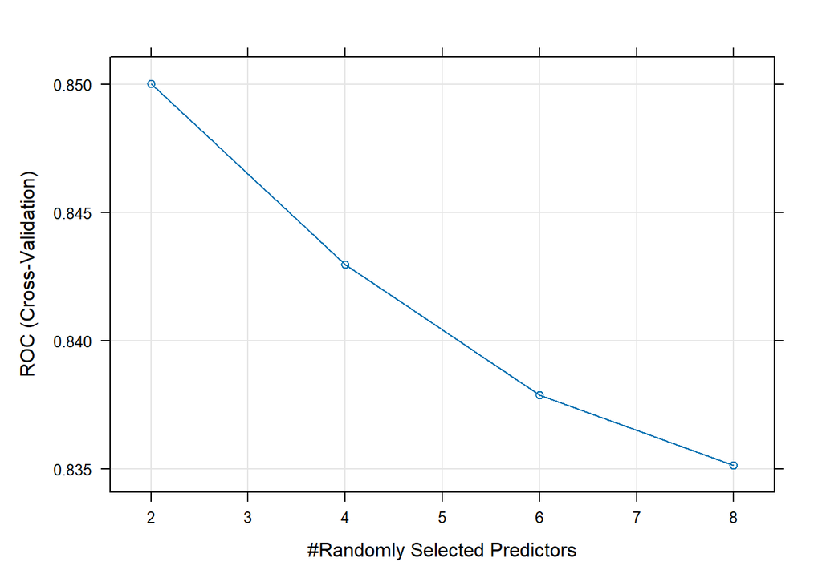

```r
plot(rf_model)
```

#3.8.2. Tune the parameter mtry (features per split): 2, 4, 6, 8. #3.8.3. Set ntree = 500 (number of trees).

```r
rf_model$finalModel
```

```
##
## Call:
##  randomForest(x = x, y = y, ntree = 500, mtry = param$mtry)
##                Type of random forest: classification
##                      Number of trees: 500
## No. of variables tried at each split: 2
##
##         OOB estimate of  error rate: 21.19%
## Confusion matrix:
##       No Yes class.error
## No  1138  87  0.07102041
## Yes  293 275  0.51584507
```

#3.8.4. Report the optimal mtry value.

```r
rf_model$bestTune
```

```
##   mtry
## 1    2
```

#3.8.5. Extract and plot variable importance.

```r
varImp(rf_model)
```

```
## rf variable importance
##
##                               Overall
## MonthlyCharges                100.000
## TenureMonths                   50.563
## SatisfactionScore              50.301
## Age                            33.193
## ContractTypeTwo-year           18.057
## InternetServiceFiber optic      4.262
## InternetServiceNo               3.162
## LoyaltyProgramYes               2.350
## ContractTypeOne-year            2.235
## GenderMale                      2.216
## PaymentMethodElectronic check   1.456
## PaymentMethodCredit card        0.714
## PaymentMethodMailed check       0.000
```

#3.8.6. Identify the top 5 most important predictors for churn.

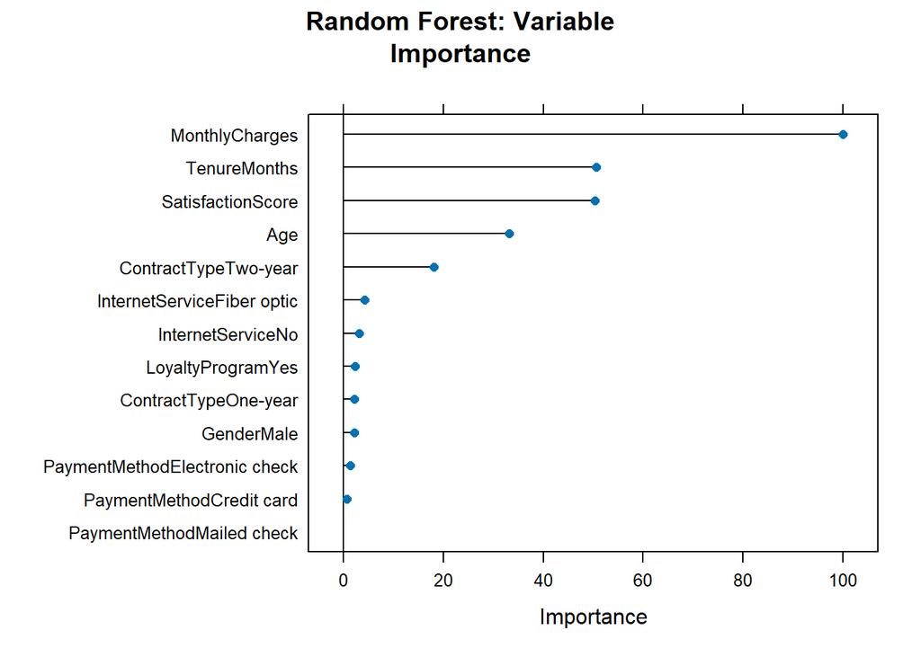

```r
plot(varImp(rf_model), main = "Random Forest: Variable
Importance")
```

```r
# Check dimensions of your test sets
cat("Original test data:", nrow(test_data), "rows\n")
```

```
## Original test data: 767 rows
```

```r
cat("Scaled test data:", nrow(test_scaled), "rows\n")
```

```
## Scaled test data: 767 rows
```

```r
# Verify Churn is a factor
class(test_data$Churn)
```

```
## [1] "factor"
```

```r
levels(test_data$Churn)
```

```
## [1] "No"  "Yes"
```

3.9 Task 9: Model Evaluation and Comparison (20 Marks)

#3.9.1. Predict the class and probabilities on the test set for all 4 models.

```r
# Predictions for all models
log_pred <- predict(log_model, test_data)
log_probs <- predict(log_model, test_data, type = "prob")

knn_pred <- predict(knn_model, test_scaled)
knn_probs <- predict(knn_model, test_scaled, type = "prob")

svm_pred <- predict(svm_model, test_scaled)
svm_probs <- predict(svm_model, test_scaled, type = "prob")

rf_pred <- predict(rf_model, test_data)
rf_probs <- predict(rf_model, test_data, type = "prob")
```

#3.9.1b extract metrics

```r
extract_metrics <- function(cm) {
  data.frame(
    Accuracy    = round(cm$overall["Accuracy"], 4),
    Sensitivity = round(cm$byClass["Sensitivity"], 4),
    Specificity = round(cm$byClass["Specificity"], 4),
    Precision   = round(cm$byClass[["Pos Pred Value"]], 4),
    F1_Score    = round(cm$byClass["F1"], 4),
    Kappa       = round(cm$overall["Kappa"], 4)
  )
}

metrics_table <- rbind(
  c("Logistic Regression", extract_metrics(confusionMatrix(log_pred, test_data$Churn, positive="Yes"))),
  c("KNN", extract_metrics(confusionMatrix(knn_pred, test_scaled$Churn, positive="Yes"))),
  c("SVM", extract_metrics(confusionMatrix(svm_pred, test_scaled$Churn, positive="Yes"))),
  c("Random Forest", extract_metrics(confusionMatrix(rf_pred, test_data$Churn, positive="Yes")))
)
colnames(metrics_table)[1] <- "Model"
metrics_table <- as.data.frame(metrics_table)
print(metrics_table)
```

```
##                 Model Accuracy Sensitivity Specificity Precision F1_Score
## 1 Logistic Regression    0.811      0.6626      0.8798    0.7188   0.6895
## 2                 KNN   0.7966      0.6049      0.8855    0.7101   0.6533
## 3                 SVM    0.807      0.6626       0.874    0.7093   0.6851
## 4       Random Forest   0.7862      0.4897      0.9237    0.7484    0.592
##    Kappa
## 1 0.5539
## 2 0.5107
## 3 0.5462
## 4 0.4556
```

#3.9.2. For each model, generate a Confusion Matrix and report: • Accuracy• Sensitivity (Recall)• Specificity• Precision (PPV)• F1-Score• Kappa

```r
# Confusion Matrix for Logistic regression
confusionMatrix(log_pred, test_data$Churn, positive = "Yes")
```

```
## Confusion Matrix and Statistics
##
##           Reference
## Prediction  No Yes
##        No  461  82
##        Yes  63 161
##
##                Accuracy : 0.811
##                  95% CI : (0.7814, 0.8381)
##     No Information Rate : 0.6832
##     P-Value [Acc > NIR] : 1.163e-15
##
##                   Kappa : 0.5539
##
##  Mcnemar's Test P-Value : 0.135
##
##             Sensitivity : 0.6626
##             Specificity : 0.8798
##          Pos Pred Value : 0.7188
##          Neg Pred Value : 0.8490
##              Prevalence : 0.3168
##          Detection Rate : 0.2099
##    Detection Prevalence : 0.2920
##       Balanced Accuracy : 0.7712
##
##        'Positive' Class : Yes
##
```

```r
confusionMatrix(knn_pred, test_scaled$Churn, positive = "Yes")
```

```
## Confusion Matrix and Statistics
##
##           Reference
## Prediction  No Yes
##        No  464  96
##        Yes  60 147
##
##                Accuracy : 0.7966
##                  95% CI : (0.7664, 0.8246)
##     No Information Rate : 0.6832
##     P-Value [Acc > NIR] : 1.453e-12
##
##                   Kappa : 0.5107
##
##  Mcnemar's Test P-Value : 0.005075
##
##             Sensitivity : 0.6049
##             Specificity : 0.8855
##          Pos Pred Value : 0.7101
##          Neg Pred Value : 0.8286
##              Prevalence : 0.3168
##          Detection Rate : 0.1917
##    Detection Prevalence : 0.2699
##       Balanced Accuracy : 0.7452
##
##        'Positive' Class : Yes
##
```

```r
confusionMatrix(svm_pred, test_scaled$Churn, positive = "Yes")
```

```
## Confusion Matrix and Statistics
##
##           Reference
## Prediction  No Yes
##        No  458  82
##        Yes  66 161
##
##                Accuracy : 0.807
##                  95% CI : (0.7773, 0.8344)
##     No Information Rate : 0.6832
##     P-Value [Acc > NIR] : 8.969e-15
##
##                   Kappa : 0.5462
##
##  Mcnemar's Test P-Value : 0.2176
##
##             Sensitivity : 0.6626
##             Specificity : 0.8740
##          Pos Pred Value : 0.7093
##          Neg Pred Value : 0.8481
##              Prevalence : 0.3168
##          Detection Rate : 0.2099
##    Detection Prevalence : 0.2960
##       Balanced Accuracy : 0.7683
##
##        'Positive' Class : Yes
##
```

```r
confusionMatrix(rf_pred, test_data$Churn, positive = "Yes")
```

```
## Confusion Matrix and Statistics
##
##           Reference
## Prediction  No Yes
##        No  484 124
##        Yes  40 119
##
##                Accuracy : 0.7862
##                  95% CI : (0.7554, 0.8147)
##     No Information Rate : 0.6832
##     P-Value [Acc > NIR] : 1.419e-10
##
##                   Kappa : 0.4556
##
##  Mcnemar's Test P-Value : 9.099e-11
##
##             Sensitivity : 0.4897
##             Specificity : 0.9237
##          Pos Pred Value : 0.7484
##          Neg Pred Value : 0.7961
##              Prevalence : 0.3168
##          Detection Rate : 0.1551
##    Detection Prevalence : 0.2073
##       Balanced Accuracy : 0.7067
##
##        'Positive' Class : Yes
##
```

#3.9.3. Plot ROC curves for all 4 models on the same graph.

```r
# ROC Curves
log_roc <- roc(test_data$Churn, log_probs$Yes)
knn_roc <- roc(test_data$Churn, knn_probs$Yes)
svm_roc <- roc(test_data$Churn, svm_probs$Yes)
rf_roc <- roc(test_data$Churn, rf_probs$Yes)
```

#3.9.4. Calculate and compare AUC values for all models.

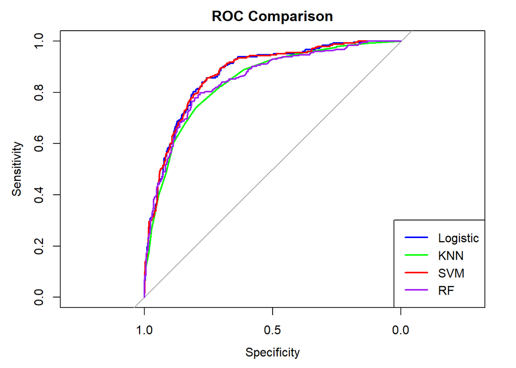

```r
 plot(log_roc, col = "blue", lwd = 2, main = "ROC Comparison")
lines(knn_roc, col = "green", lwd = 2)
lines(svm_roc, col = "red", lwd = 2)
lines(rf_roc, col = "purple", lwd = 2)
 legend("bottomright",
        legend = c("Logistic", "KNN", "SVM", "RF"),
col = c("blue", "green", "red", "purple"),
lwd = 2)
```

#3.9.5. Create a comparison table summarizing all metrics.

```r
auc_values <- data.frame(
  Model = c("Logistic", "KNN", "SVM", "Random Forest"),
  AUC = c(
    as.numeric(auc(log_roc)),
    as.numeric(auc(knn_roc)),
    as.numeric(auc(svm_roc)),
    as.numeric(auc(rf_roc))
  )
)

print(auc_values)
```

```
##           Model       AUC
## 1      Logistic 0.8710929
## 2           KNN 0.8425690
## 3           SVM 0.8707395
## 4 Random Forest 0.8477837
```

#3.9.6. Rank the models from best to worst based on AUC.

```r
model_results <- auc_values[order(-auc_values$AUC), ]
model_results
```

```
##           Model       AUC
## 1      Logistic 0.8710929
## 3           SVM 0.8707395
## 4 Random Forest 0.8477837
## 2           KNN 0.8425690
```

#visulslization

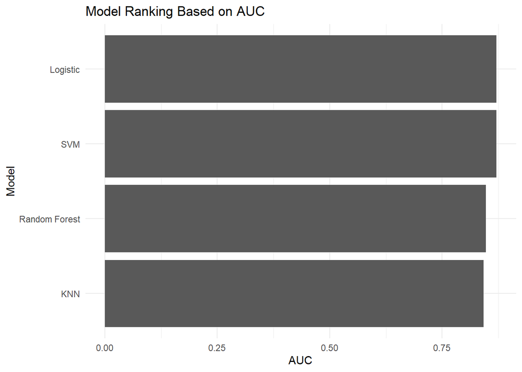

```r
ggplot(model_results, aes(x = reorder(Model, AUC), y = AUC)) +
  geom_col() +
  coord_flip() +
  labs(
    title = "Model Ranking Based on AUC",
    x = "Model",
    y = "AUC"
  ) +
  theme_minimal()
```

3.10 Task 10: Interpretation and Recommendations (15 Marks) #3.10.1. Based on your results, answer the following: #3.10.1.a)Which model performed best? Justify using metrics. logistic regression The Logistic Regression model performed best, achieving the highest AUC of 0.8711. AUC measures the model’s ability to distinguish between churn and non-churn customers, and a higher value indicates better classification performance. Since Logistic Regression has the highest AUC among all models, it demonstrates the strongest predictive capability.

#3.10.1.c)Was feature scaling necessary for all models? Explain. No, feature scaling was not necessary for all models.

Required for:KNN, SVM These models rely on distance calculations, so scaling ensures all variables contribute equally. Not required for: Logistic Regression Random Forest These models are not distance-based and are generally unaffected by differences in feature scale.

#3.10.1.d)Did cross-validation improve model reliability? Explain. Yes, cross-validation improved model reliability.

It reduces the risk of overfitting Provides a more robust estimate of model performance Ensures results are not dependent on a single train-test split Improves generalizability to unseen data

#3.10.2. For the best model, identify the top 3 risk factors for churn. Based on Logistic Regression (interpretable model), the top risk factors are typically identified using coefficients:

TenureMonths (negative effect) → Shorter tenure increases churn risk MonthlyCharges (positive effect) → Higher charges increase likelihood of churn SatisfactionScore (negative effect) → Lower satisfaction strongly increases churn

👉 Interpretation:

Customers who are new, paying more, and less satisfied are most likely to churn

#3.10.3. Discuss the trade-offs between model accuracy and interpretability. There is a clear trade-off:

Logistic Regression ✅ High interpretability ✅ Easy to explain coefficients ✅ Good performance (best AUC) ❌ May miss complex relationships Random Forest / SVM ✅ Can capture complex patterns ❌ Hard to interpret (“black-box” models)

👉 In this case, Logistic Regression provides both strong performance and interpretability, making it the most practical choice.

#3.10.4. Provide recommendations for customer retention strategies based on your findings. Based on findings:

🎯 Target high-risk customers: New customers (low tenure) Customers with high monthly charges Customers with low satisfaction scores 📌 Suggested strategies: Offer loyalty incentives for new customers Provide discounts or flexible pricing plans Improve customer service and support experience Use early warning systems to identify likely churners Personalize engagement (emails, offers, follow-ups)

#3.10.5. Discuss any limitations of your analysis (e.g., observational data, potential confounders). Observational data: Cannot establish causality, only associations Potential confounders: Important variables may be missing (e.g., competitor offers, income level) Model assumptions: Logistic Regression assumes linear relationships Data quality issues: Possible measurement errors or bias Generalizability: Results may not apply to other datasets or industries

Logistic Regression emerged as the best-performing model with the highest AUC while maintaining strong interpretability. This makes it highly suitable for both prediction and decision-making. The analysis highlights key churn drivers such as tenure, cost, and satisfaction, providing actionable insights for improving customer retention.

Report Guidelines Your report should include: • Executive summary (1 paragraph) • Methodology description • Results with tables and figures • Model comparison table • Interpretation and recommendations • Limitations and future work • Appendix with complete R code

4 Submission Guidelines • File Format: Submit a single ZIP file named ML_Assignment3_YourName.zip. • Contents: 1. Report (PDF) containing answers, plots, tables, and interpretations (max 15 pages). 2. R Script (.R) or R Markdown (.Rmd) with all code and comments. 3. The dataset (if modified). • Naming Convention: YourName_StudentID_ML_Assignment3.pdf • Submission Portal: Upload to the CDAM Learning Management System. • Deadline: 24th April 2026, 11:59 PM EAT